# Сравнение линейных моделей

## Мы рассмотрим

- Вложенные модели
- Тестирование значимости отдельных предикторов при помощи частного F-критерия
- Принципы отбора моделей
- Упрощение моделей

### Вы сможете

- Определять, какие модели являются вложенными
- Сравнивать вложенные модели при помощи частного F-критерия
- Объяснить связь между качеством описания существующих данных и краткостью модели
- Объяснить, что такое “переобучение” модели
- Упростить линейную модель при помощи частного F-критерия, следуя обратному пошаговому алгоритму

## Модель множественной линейной регрессии с прошлой лекции

## Пример: птицы в лесах Австралии

От каких характеристик лесного участка зависит обилие птиц в лесах юго-западной Виктории, Австралия (Loyn, 1987)

Переменных много, мы хотим из них выбрать **оптимальный небольшой** набор.

56 лесных участков:

- ABUND - обилие птиц
- AREA - площадь участка
- YRISOL - год изоляции участка
- DIST - расстояние до ближайшего леса
- LDIST - расстояние до ближайшего большого леса
- GRAZE - пастбищная нагрузка (1-5)
- ALT - высота над уровнем моря

Пример из кн. Quinn, Keugh, 2002, данные из Loyn, 1987)

## Модель из прошлой лекции

```r
bird <- read.csv("data/loyn.csv")
bird$logAREA <- log(bird$AREA)
bird$logDIST <- log(bird$DIST)
bird$logLDIST <- log(bird$LDIST)
mod2 <- lm(ABUND ~ logAREA + YRISOL + logDIST + logLDIST + ALT, data = bird)
```

\[\begin{aligned}\widehat{ABUND}_i = &-226.00 + 3.69 \cdot logAREA_i + 0.12 \cdot YRISOL_i \\ &- 0.10 \cdot logDIST_i - 0.33 \cdot logLDIST_i + 0.03 \cdot ALT_i\\ \end{aligned}\]

- Проверим еще одним способом, влияют ли предикторы.
- Разберемся, можно ли оптимизировать модель.

## Вложенные модели (nested models)

## Вложенные модели (nested models)

Две модели являются *вложенными*, если одну из них можно получить из другой путем удаления некоторых предикторов.

Удаление предиктора - коэффициент при данном предикторе равен нулю.

### Полная модель (full model)

М1: \(y _i = b _0 + b _1 x _{1i} + b _2 x _{2i} + e _i\)

### Неполные модели (reduced models)

М2: \(y _i = b _0 + b _1 x _{1i} + e _i\)

М3: \(y _i = b _0 + b _2 x _{2i} + e _i\)

M2 вложена в M1  
M3 вложена в M1  
M2 и M3 не вложены друг в друга

### Нулевая модель (null model), вложена в полную (M1) и в неполные (M2, M3)

\(y _i = b _0 + e _i\)

## Задание

Для тренировки запишем вложенные модели для данной полной модели

(1)\(y _i = b _0 + b _1 x _{1i} + b _2 x _{2i} + b _3 x _{3i} + e _i\)

## Решение

Для тренировки запишем вложенные модели для данной полной модели

(1)\(y _i = b _0 + b _1 x _{1i} + b _2 x _{2i} + b _3 x _{3i} + e _i\)

Модели:

- (2)\(y _i = b _0 + b _1 x _{1i} + b _2 x _{2i} + e _i\)
- (3)\(y _i = b _0 + b _1 x _{1i} + b _3 x _{3i} + e _i\)
- (4)\(y _i = b _0 + b _2 x _{2i} + b _3 x _{3i} + e _i\)
- (5)\(y _i = b _0 + b _1 x _{1i} + e _i\)
- (6)\(y _i = b _0 + b _2 x _{2i} + e _i\)
- (7)\(y _i = b _0 + b _3 x _{3i} + e _i\)
- (8)\(y _i = b _0 + e _i\)

Вложенность:

- (2)-(4)- вложены в (1)
- (5)-(7)- вложены в (1), при этом
  - (5)вложена в (1), (2), (3);
  - (6)вложена в (1), (2), (4);
  - (7)вложена в (1), (3), (4)
- (8)- нулевая модель - вложена во все

## Частный F-критерий

## Сравнение вложенных линейных моделей при помощи F-критерия

### Полная модель (со всеми предикторами)

\(y _i = b _0 + b _1 x _{1i} + \ldots + b _k x _{ki} + b _{l} x _{li} + e _i\)

\(SS_{r, full}\), \(df _{r, full} = p - 1\)

\(SS_{e, full}\), \(df _{e, full} = n - p\)

### Уменьшенная модель с \((p - 1)\) параметрами (например, без предиктора \(b _{l} x _{li}\))

\(y _i = b _0 + b _1 x _{1i} + \ldots + b _k x _{ki} + e _i\)

\(SS_{r, reduced}\), \(df _{r, reduced} = (p - 1) - 1\)

\(SS _{e, reduced}\), \(df _{e, reduced} = n - (p - 1)\)

## Полная модель всегда будет лучше

\(SS_{r, full} > SS _{r, reduced}\)

или то же самое:

\(SS_{e, full} < SS _{e, reduced}\)

Можно оценить, насколько именно полная модель лучше уменьшенной

(= или насколько уменьшенная модель хуже полной).

## Частный F-критерий оценивает разницу объясненной дисперсии между моделями

\[F = \frac {(SS_{e, reduced} - SS _{e, full})/(df _{e, reduced} - df _{e, full})}{SS _{e, full} / df _{e, full}}\]

**Если модель значимо ухудшается от удаления предиктора, то влияние этого предиктора значимо.**

## Краткое обозначение частного F-критерия

Чтобы проверить значимость предиктора `ALT`, нам нужно сравнить две модели

`ABUND ~ logAREA + YRISOL + logDIST + logLDIST + ALT`  
`ABUND ~ logAREA + YRISOL + logDIST + logLDIST`

Это можно обозначить

\(F_{(\text{ALT | logAREA, YRISOL, logDIST, logLDIST})}\)

А разницу остаточных сумм квадратов \(SS_{e, reduced} - SS _{e, full}\), которую мы тестируем, можно обозначить

\(SS_{(\text{ALT | logAREA, YRISOL, logDIST, logLDIST})}\)

## Частный F-критерий в R `anova(модель_1, модель_2)`

Если высота над уровнем моря входит в модель после учета влияния остальных предикторов, то его влияние не значимо (\(F = 1.84\), \(p = 0.18\)).

\(F_{(\text{ALT | logAREA, YRISOL, logDIST, logLDIST})}\)

```r
mod2_reduced <- update(mod2, . ~ . - ALT)
anova(mod2_reduced, mod2)
```

```
## Analysis of Variance Table
##
## Model 1: ABUND ~ logAREA + YRISOL + logDIST + logLDIST
## Model 2: ABUND ~ logAREA + YRISOL + logDIST + logLDIST + ALT
##   Res.Df  RSS Df Sum of Sq    F Pr(>F)
## 1     51 2206
## 2     50 2128  1      78.2 1.84   0.18
```

## Результаты F- и t-тестов эквивалентны

\(t^2 = F\)

\(t^2\) равен значению частной F-статистики для этого фактора, **когда он входит в модель последним**.

```r
F_val <- anova(mod2, mod2_reduced)[2, 'F']
F_val
```

```
## [1] 1.84
```

```r
t_val <- coef(summary(mod2))['ALT', 't value']
t_val^2
```

```
## [1] 1.84
```

## Характер влияния предиктора зависит от состава модели (и значит зависит от порядка тестирования)

Если высота над уровнем моря — единственный предиктор в модели, то его влияние статистически значимо (\(F = 9.45\), \(p < 0.05\))

\(F_{(\text{ALT})}\)

```r
mod_ALT1 <- lm(ABUND ~ ALT, data = bird)
mod_null <- lm(ABUND ~ 1, data = bird)
anova(mod_null, mod_ALT1)
```

```
## Analysis of Variance Table
##
## Model 1: ABUND ~ 1
## Model 2: ABUND ~ ALT
##   Res.Df  RSS Df Sum of Sq    F Pr(>F)
## 1     55 6338
## 2     54 5394  1       944 9.45 0.0033 **
## ---
## Signif. codes:  0 '***' 0.001 '**' 0.01 '*' 0.05 '.' 0.1 ' ' 1
```

## I и II типы сумм квадратов

## Порядок проведения сравнений при F-тестах (типы сумм квадратов)

`Y ~ A + B + C`

### I тип сумм квадратов (SS type I)

Последовательно вычисляем вклады предикторов при условии, что все предыдущие включены в модель

- \(SS_{A}\)
- \(SS_{B|A}\)
- \(SS_{C|A, B}\)

### II тип сумм квадратов (SS type II)

Поочередно вычисляем вклад каждого предиктора при условии, что все остальные включены в модель

- \(SS_{A|B, C}\)
- \(SS_{B|A, C}\)
- \(SS_{C|A, B}\)

## Последовательное тестирование `anova(модель)`

```r
anova(mod2)
```

```
## Analysis of Variance Table
##
## Response: ABUND
##           Df Sum Sq Mean Sq F value  Pr(>F)
## logAREA    1   3471    3471   81.56 4.4e-12 ***
## YRISOL     1    607     607   14.27 0.00042 ***
## logDIST    1     28      28    0.67 0.41737
## logLDIST   1     25      25    0.59 0.44687
## ALT        1     78      78    1.84 0.18137
## Residuals 50   2128      43
## ---
## Signif. codes:  0 '***' 0.001 '**' 0.01 '*' 0.05 '.' 0.1 ' ' 1
```

## Осторожно, при последовательном тестировании результат зависит от порядка предикторов

Если мы поставим `ALT` первым, то изменится SS для других предикторов, а влияние самого `ALT` станет значимым (т.к. оно оценено без учета других предикторов).

```r
mod2_reordered <- lm(ABUND ~ ALT + logAREA + YRISOL + logDIST + logLDIST,
                     data = bird)
anova(mod2_reordered)
```

```
## Analysis of Variance Table
##
## Response: ABUND
##           Df Sum Sq Mean Sq F value        Pr(>F)
## ALT        1    944     944   22.17 0.00002017033 ***
## logAREA    1   2755    2755   64.74 0.00000000014 ***
## YRISOL     1    502     502   11.81        0.0012 **
## logDIST    1      4       4    0.09        0.7698
## logLDIST   1      5       5    0.12        0.7290
## Residuals 50   2128      43
## ---
## Signif. codes:  0 '***' 0.001 '**' 0.01 '*' 0.05 '.' 0.1 ' ' 1
```

## Поочередное тестирование `Anova(модель)` или `drop1()`

```r
library(car)
Anova(mod2)
```

```
## Anova Table (Type II tests)
##
## Response: ABUND
##           Sum Sq Df F value     Pr(>F)
## logAREA     1614  1   37.92 0.00000012 ***
## YRISOL       437  1   10.26     0.0024 **
## logDIST        0  1    0.01     0.9303
## logLDIST       5  1    0.12     0.7290
## ALT           78  1    1.84     0.1814
## Residuals   2128 50
## ---
## Signif. codes:  0 '***' 0.001 '**' 0.01 '*' 0.05 '.' 0.1 ' ' 1
```

```r
# drop1(mod2, test = 'F')
```

## При поочередном тестировании результат НЕ зависит от порядка предикторов

```r
Anova(mod2_reordered)
```

```
## Anova Table (Type II tests)
##
## Response: ABUND
##           Sum Sq Df F value     Pr(>F)
## ALT           78  1    1.84     0.1814
## logAREA     1614  1   37.92 0.00000012 ***
## YRISOL       437  1   10.26     0.0024 **
## logDIST        0  1    0.01     0.9303
## logLDIST       5  1    0.12     0.7290
## Residuals   2128 50
## ---
## Signif. codes:  0 '***' 0.001 '**' 0.01 '*' 0.05 '.' 0.1 ' ' 1
```

## Есть и другое применение F-теста

F-тест, который мы только что рассмотрели, можно использовать не только для сравнения моделей и тестирования значимости отдельных предикторов.

```r
Anova(mod2)
```

```
## Anova Table (Type II tests)
##
## Response: ABUND
##           Sum Sq Df F value     Pr(>F)
## logAREA     1614  1   37.92 0.00000012 ***
## YRISOL       437  1   10.26     0.0024 **
## logDIST        0  1    0.01     0.9303
## logLDIST       5  1    0.12     0.7290
## ALT           78  1    1.84     0.1814
## Residuals   2128 50
## ---
## Signif. codes:  0 '***' 0.001 '**' 0.01 '*' 0.05 '.' 0.1 ' ' 1
```

Не все предикторы влияют. Может, попытаться упростить модель?

## Принципы выбора лучшей линейной модели

“Essentially, all models are wrong,  
but some are useful”  
Georg E. P. Box

## Важно не только тестирование гипотез, но и построение моделей

- Проверка соответствия наблюдаемых данных предполагаемой связи между зависимой перменной и предикторами:
  - оценки параметров,
  - **тестирование гипотез**,
  - оценка объясненной изменчивости (\(R^2\)),
  - анализ остатков
- **Построение моделей** для предсказания значений в новых условиях:
  - Выбор оптимальной модели
  - Оценка предсказательной способности модели **на новых данных**

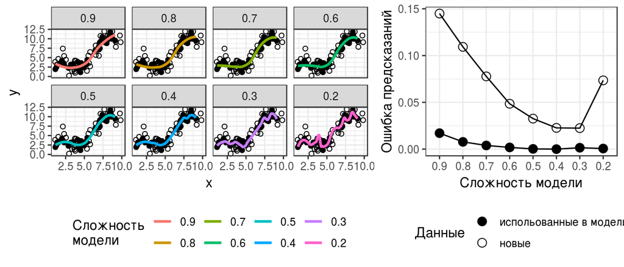

## Зачем может понадобится упрощать модель?

### Какую модель можно подобрать для описания этой закономерности?

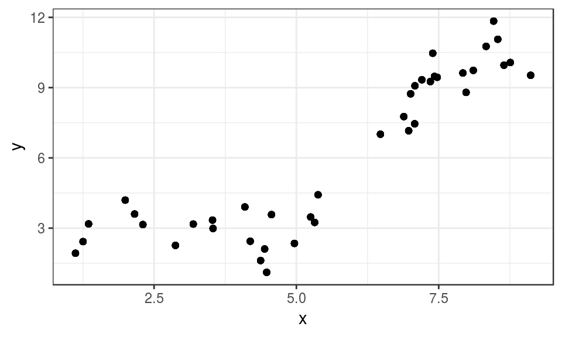

- Эти данные можно смоделировать очень разными способами. Мы попробуем посмотреть, как это будет выглядеть на примере loess— локальной полиномиальной регрессии. (Если интересно, [подробнее о loess-регрессии](https://www.mathworks.com/help/curvefit/smoothing-data.html#bq_6ys3-4))

## Какая из этих моделей лучше описывает данные?

На этих графиках показаны предсказания loess-регрессии для одних и тех же исходных данных.

Cложность модели — в общем случае, это число параметров. Для loess-регрессии сложность модели отражает степень сглаживания: у более сложных моделей маленькая степень сглаживания.

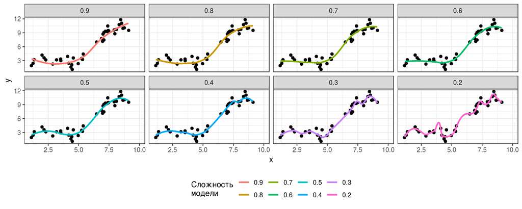

- Простые модели недообучены (underfitted) — слишком мало параметров, предсказания неточны.
- Сложные модели переобучены (overfitted) — слишком много параметров, предсказывают еще и случайный шум.

## Что будет, если получить предсказания моделей на новых данных?

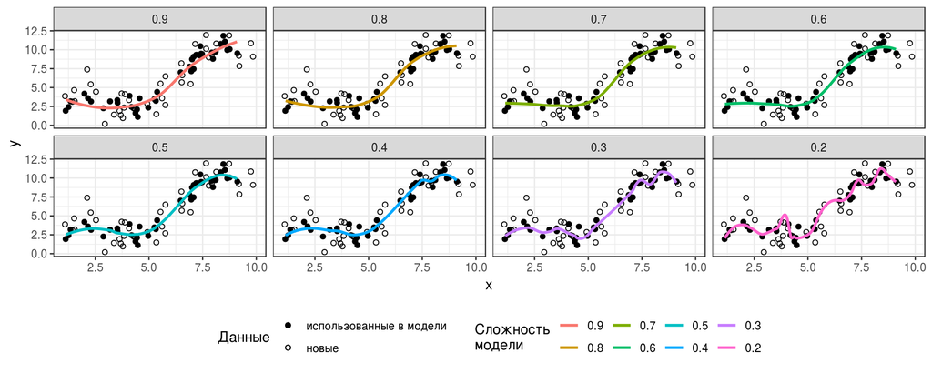

На новых данных предсказания моделей не будут идеальными.

## Как при усложнении модели меняется качество предсказаний?

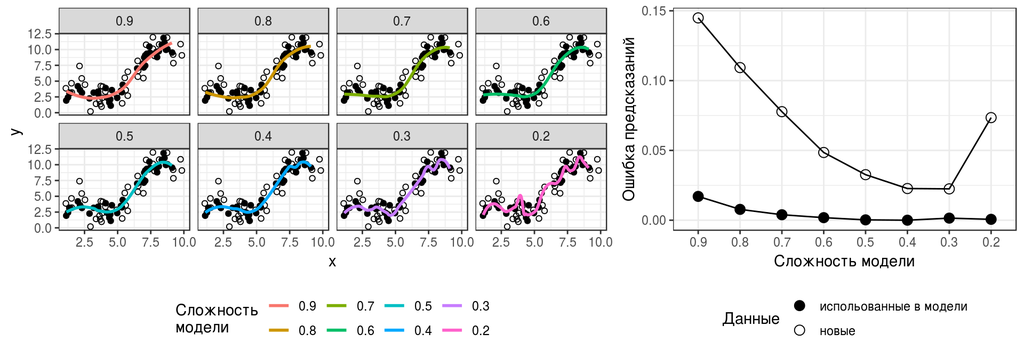

Ошибка предсказаний на новых данных практически всегда больше, чем на исходных данных. Более сложные модели лучше описывают существующие данные, но на новых данных их предсказания хуже.

Обычно при усложнении модели:

- ошибки предсказаний на исходных данных убывают (иногда, до какого-то уровня) (L-образная кривая)
- ошибки предсказаний на новых данных убывают, затем возрастают из-за переобучения (U-образная кривая)

## Погрешность и точность

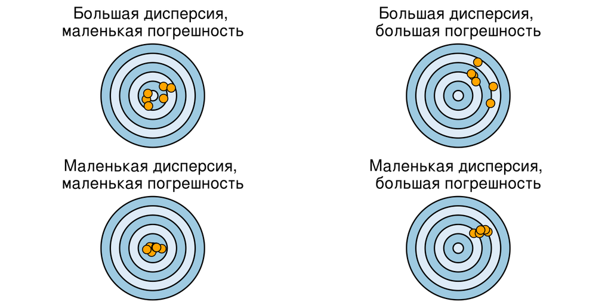

- Погрешность (accuracy, точность)— отсутствие погрешности (bias).
- Точность (precision, тоже точность — другой аспект) — разброс значений

Предсказания, сделанные на новых данных, будут отличаться от истинных значений не только из-за погрешности или неточности. Еще один источник отличий — это так называемая неснижаемая ошибка.

## Компромисс между погрешностью и разбросом значений предсказаний (Bias-Variance Tradeoff)

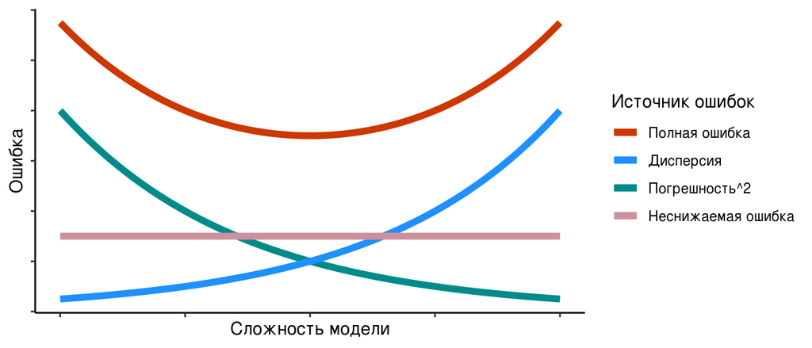

\[Полная~ошибка = Дисперсия + (Погрешность)^2 + Неснижаемая~ошибка\] При увеличении сложности модели снижается погрешность предсказаний, но возрастает их разброс. Поэтому общая ошибка предсказаний велика у недообученных или переобученных моделей, а у моделей средней сложности она будет минимальной.

## Критерии и методы выбора моделей зависят от задачи

**Объяснение закономерностей, описание функциональной зависимости**

- Нужна точность оценки параметров
- Нужны точные тесты влияния предикторов: F-тесты или тесты отношения правдоподобий (likelihood-ratio tests)

**Предсказание значений зависимой переменной**

- Нужна простая модель: “информационные” критерии (АIC, BIC, и т.д.)
- Нужна оценка качества модели на данных, которые не использовались для ее первоначальной подгонки: методы ресамплинга (кросс-валидация, бутстреп)

### Не позволяйте компьютеру думать за вас!

- Хорошая модель должна соответствовать условиям применимости, иначе вы не сможете доверять результатам тестов.
- Другие соображения: разумность, целесообразность модели, простота, ценность выводов, важность предикторов.

## Отбор моделей

## Упрощение линейных моделей при помощи частного F-критерия

Постепенно удаляем предикторы. Модели обязательно должны быть вложенными! *

### Обратный пошаговый алгоритм (backward selection)

- 1.Подбираем полную модель
- Повторяем 2-3 для каждого из предикторов:
- 2.Удаляем один предиктор (строим уменьшенную модель)
- 3.Тестируем отличие уменьшенной модели от полной
- 4.Выбираем предиктор для окончательного удаления: это предиктор, удаление которого минимально ухудшает модель. Модель без него будет “полной” для следующего раунда выбора оптимальной модели.
- Повторяем 1-4 до тех пор, пока что-то можно удалить.
- — **Важно!** Начинать упрощать модель нужно со взаимодействий между предикторами. Если взаимодействие из модели удалить нельзя, то нельзя удалять и отдельно стоящие предикторы, из которых оно состоит. Но мы поговорим о взаимодействиях позже.

## Влияют ли предикторы?

- Можем попробовать оптимизировать модель

```r
summary(mod2)
```

```
##
## Call:
## lm(formula = ABUND ~ logAREA + YRISOL + logDIST + logLDIST +
##     ALT, data = bird)
##
## Residuals:
##     Min      1Q  Median      3Q     Max
## -15.439  -3.669   0.332   2.765  15.759
##
## Coefficients:
##              Estimate Std. Error t value   Pr(>|t|)
## (Intercept) -226.0006    74.2526   -3.04     0.0037 **
## logAREA        3.6882     0.5989    6.16 0.00000012 ***
## YRISOL         0.1207     0.0377    3.20     0.0024 **
## logDIST       -0.1033     1.1759   -0.09     0.9303
## logLDIST      -0.3281     0.9417   -0.35     0.7290
## ALT            0.0318     0.0235    1.36     0.1814
## ---
## Signif. codes:  0 '***' 0.001 '**' 0.01 '*' 0.05 '.' 0.1 ' ' 1
##
## Residual standard error: 6.52 on 50 degrees of freedom
## Multiple R-squared:  0.664,  Adjusted R-squared:  0.631
## F-statistic: 19.8 on 5 and 50 DF,  p-value: 7.97e-11
```

## Что происходит на каждом шаге обратного пошагового алгоритма?

`anova(модель_1, модель_2)`

Подбираем полную модель, удаляем предикторы по-одному, тестируем ухудшилась ли модель. Для окончательного удаления на этом шаге выбираем предиктор, удаление которого меньше всего ее ухудшает.

```r
mod3 <- update(mod2, . ~ . - logAREA)
anova(mod2, mod3)
mod4 <- update(mod3, . ~ . - YRISOL)
anova(mod2, mod4)
mod5 <- update(mod3, . ~ . - logDIST)
anova(mod2, mod5)
mod6 <- update(mod3, . ~ . - logLDIST)
anova(mod2, mod6)
mod7 <- update(mod3, . ~ . - ALT)
anova(mod2, mod7)
```

- Но мы пойдем другим путем. Все эти действия может выполнить одна функция `drop1()`

## Частный F-критерий при помощи `drop1()` (шаг 1)

Тестируем значимость всех предикторов за один раз. Затем выбираем предиктор, удаление которого меньше всего ухудшает модель.

```r
drop1(mod2, test = "F")
```

```
## Single term deletions
##
## Model:
## ABUND ~ logAREA + YRISOL + logDIST + logLDIST + ALT
##          Df Sum of Sq  RSS AIC F value     Pr(>F)
## <none>                2128 216
## logAREA   1      1614 3742 245   37.92 0.00000012 ***
## YRISOL    1       437 2565 224   10.26     0.0024 **
## logDIST   1         0 2128 214    0.01     0.9303
## logLDIST  1         5 2133 214    0.12     0.7290
## ALT       1        78 2206 216    1.84     0.1814
## ---
## Signif. codes:  0 '***' 0.001 '**' 0.01 '*' 0.05 '.' 0.1 ' ' 1
```

```r
# Нужно убрать logDIST
```

## Тестируем предикторы (шаг 2)

Удаляем выбранный предиктор и повторяем тесты снова. И т.д.

```r
# Убрали logDIST
mod3 <- update(mod2, . ~ . - logDIST)
drop1(mod3, test = "F")
```

```
## Single term deletions
##
## Model:
## ABUND ~ logAREA + YRISOL + logLDIST + ALT
##          Df Sum of Sq  RSS AIC F value      Pr(>F)
## <none>                2128 214
## logAREA   1      1628 3757 244   39.02 0.000000084 ***
## YRISOL    1       437 2565 222   10.48      0.0021 **
## logLDIST  1         9 2137 212    0.20      0.6532
## ALT       1        81 2209 214    1.94      0.1701
## ---
## Signif. codes:  0 '***' 0.001 '**' 0.01 '*' 0.05 '.' 0.1 ' ' 1
```

```r
# Нужно убрать logLDIST
```

## Тестируем предикторы (шаг 3)

```r
# Убрали logLDIST
mod4 <- update(mod3, . ~ . - logLDIST )
drop1(mod4, test = "F")
```

```
## Single term deletions
##
## Model:
## ABUND ~ logAREA + YRISOL + ALT
##         Df Sum of Sq  RSS AIC F value       Pr(>F)
## <none>               2137 212
## logAREA  1      2112 4248 248   51.39 0.0000000027 ***
## YRISOL   1       502 2639 222   12.23      0.00097 ***
## ALT      1       123 2260 213    2.99      0.08978 .
## ---
## Signif. codes:  0 '***' 0.001 '**' 0.01 '*' 0.05 '.' 0.1 ' ' 1
```

```r
# Нужно убрать ALT
```

## Тестируем предикторы (шаг 4)

```r
# Убрали ALT
mod5 <- update(mod4, . ~ . - ALT)
drop1(mod5, test = "F")
```

```
## Single term deletions
##
## Model:
## ABUND ~ logAREA + YRISOL
##         Df Sum of Sq  RSS AIC F value        Pr(>F)
## <none>               2260 213
## logAREA  1      2473 4732 252    58.0 0.00000000046 ***
## YRISOL   1       607 2867 224    14.2       0.00041 ***
## ---
## Signif. codes:  0 '***' 0.001 '**' 0.01 '*' 0.05 '.' 0.1 ' ' 1
```

```r
# Больше ничего не убрать
```

## Итоговая модель

```r
summary(mod5)
```

```
##
## Call:
## lm(formula = ABUND ~ logAREA + YRISOL, data = bird)
##
## Residuals:
##    Min     1Q Median     3Q    Max
## -14.96  -3.80  -0.01   4.04  16.72
##
## Coefficients:
##              Estimate Std. Error t value      Pr(>|t|)
## (Intercept) -252.1952    69.5868   -3.62       0.00065 ***
## logAREA        3.7318     0.4900    7.62 0.00000000046 ***
## YRISOL         0.1352     0.0358    3.77       0.00041 ***
## ---
## Signif. codes:  0 '***' 0.001 '**' 0.01 '*' 0.05 '.' 0.1 ' ' 1
##
## Residual standard error: 6.53 on 53 degrees of freedom
## Multiple R-squared:  0.643,  Adjusted R-squared:  0.63
## F-statistic: 47.8 on 2 and 53 DF,  p-value: 1.35e-12
```

## Задание

Проверьте финальную модель на выполнение условий применимости. Дополните код

```r
library()
mod_diag <- data.frame(fortify(), bird[, c()])
# 1) График расстояния Кука
ggplot(data = , aes(x = 1:, y = .cooksd)) + geom_bar(stat = "")
# 2) График остатков от предсказанных значений
gg_resid <- ggplot(data = , aes(x = , y = )) + geom_point() + geom_hline()
gg_resid
# 3) Графики остатков от предикторов в модели и нет
res_1 <- gg_resid + aes(x = logAREA)
res_1
res_2 <- gg_resid
res_3 <- gg_resid
res_4 <- gg_resid
res_5 <- gg_resid
res_6 <- gg_resid
# все графики вместе
library()
grid.arrange(res_1, res_2, nrow = 2)
# 4) Квантильный график остатков
library()
qq
```

## Решение

### 1) График расстояния Кука

- Выбросов нет

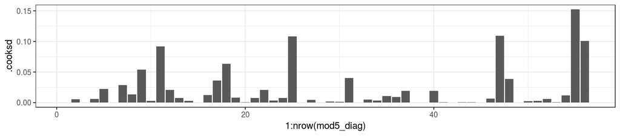

```r
mod5_diag <- data.frame(
  fortify(mod5),
  bird[, c("logDIST", "logLDIST", "GRAZE", "ALT")]
  )

ggplot(mod5_diag, aes(x = 1:nrow(mod5_diag), y = .cooksd)) +
  geom_bar(stat = "identity")
```

## Решение

### 2) График остатков от предсказанных значений

- Выбросов нет
- Гетерогенность дисперсии?
- Два наблюдения с очень большими предсказанными значениями и большими остатками. Хорошо бы проверить их.

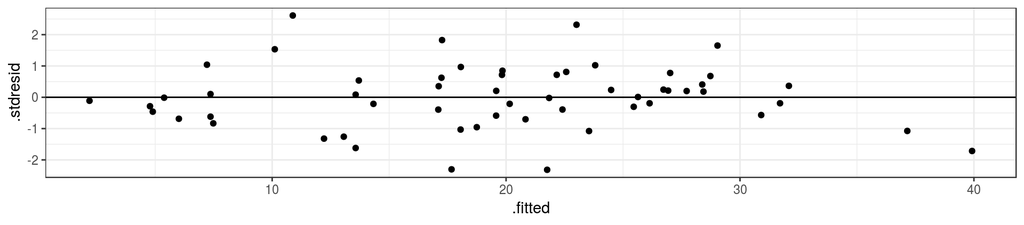

```r
gg_resid <- ggplot(data = mod5_diag, aes(x = .fitted, y = .stdresid)) +
  geom_point() + geom_hline(yintercept = 0)
gg_resid
```

## Решение

### 3) Графики остатков от предикторов в модели и нет

- Величина остатков зависит от уровня выпаса скота. Возможно, не стоило удалять эту переменную
- Есть наблюдения с экстремальными значениями предикторов (два больших леса, один далекий, один высокогорный). Хорошо бы проверить их.

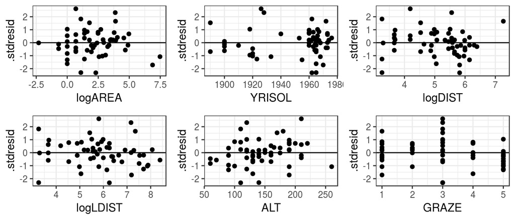

## Решение

### 3) Код для графиков остатков от предикторов в модели и нет

```r
res_1 <- gg_resid + aes(x = logAREA)
res_2 <- gg_resid + aes(x = YRISOL)
res_3 <- gg_resid + aes(x = logDIST)
res_4 <- gg_resid + aes(x = logLDIST)
res_5 <- gg_resid + aes(x = ALT)
res_6 <- gg_resid + aes(x = GRAZE)

library(gridExtra)
grid.arrange(res_1, res_2, res_3, res_4,
             res_5, res_6, nrow = 2)
```

## Решение

### 4) Квантильный график остатков

- Отклонения от нормального распределения остатков незначительны

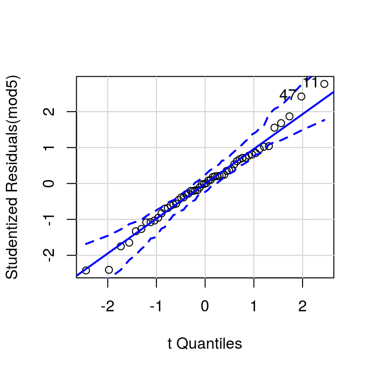

```
## [1] 11 47
```

```r
library(car)
qqPlot(mod5)
```

## Описываем финальную модель

```r
summary(mod5)
```

```
##
## Call:
## lm(formula = ABUND ~ logAREA + YRISOL, data = bird)
##
## Residuals:
##    Min     1Q Median     3Q    Max
## -14.96  -3.80  -0.01   4.04  16.72
##
## Coefficients:
##              Estimate Std. Error t value      Pr(>|t|)
## (Intercept) -252.1952    69.5868   -3.62       0.00065 ***
## logAREA        3.7318     0.4900    7.62 0.00000000046 ***
## YRISOL         0.1352     0.0358    3.77       0.00041 ***
## ---
## Signif. codes:  0 '***' 0.001 '**' 0.01 '*' 0.05 '.' 0.1 ' ' 1
##
## Residual standard error: 6.53 on 53 degrees of freedom
## Multiple R-squared:  0.643,  Adjusted R-squared:  0.63
## F-statistic: 47.8 on 2 and 53 DF,  p-value: 1.35e-12
```

## График предсказаний модели: один предиктор

\[\widehat{ABUND}_i = -252.20 + 3.73 \cdot logAREA_i + 0.14 \cdot YRISOL_i\]

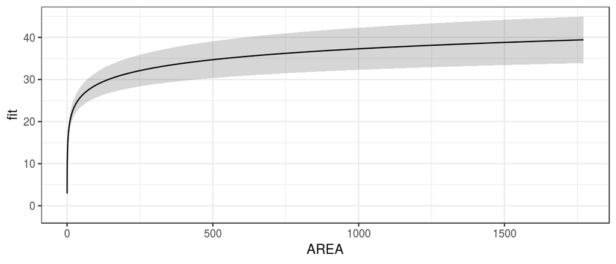

## Задание:

Постройте график предсказаний модели. Отобразите, как меняются значения зависимой переменной в зависимости от значений одного из предикторов, при условии, что другие предикторы принимают свои средние значения. Дополните этот код:

```r
# Искуственный датафрейм для предсказаний
MyData1 <- data.(
   = seq(min(   ), max(   ),    ),
  YRISOL = )
# Предсказанные значения
Predictions1 <- predict(   , newdata = ,  interval =    )
MyData1 <- data.frame(MyData1,    )
# Обратная трансформация предиктора, который будем изображать
MyData1$AREA <-
# График предсказаний модели
Pl_predict1 <- ggplot(   , aes(x = AREA, y = )) +
  geom_   (alpha = 0.2, aes(ymin = , ymax = )) +
  geom_   ()
Pl_predict1
```

## Код для графика предсказаний модели: один предиктор

\[\widehat{ABUND}_i = -252.20 + 3.73 \cdot logAREA_i + 0.14 \cdot YRISOL_i\]

```r
# Искуственный датафрейм для предсказаний
MyData1 <- data.frame(
  logAREA = seq(min(bird$logAREA), max(bird$logAREA), length.out = 100),
  YRISOL = mean(bird$YRISOL))
# Предсказанные значения
Predictions1 <- predict(mod5, newdata = MyData1,  interval = 'confidence')
MyData1 <- data.frame(MyData1, Predictions1)
# Обратная трансформация предиктора, который будем изображать
MyData1$AREA <- exp(MyData1$logAREA)
# График предсказаний модели
Pl_predict1 <- ggplot(MyData1, aes(x = AREA, y = fit)) +
  geom_ribbon(alpha = 0.2, aes(ymin = lwr, ymax = upr)) +
  geom_line()
Pl_predict1
```

## График предсказаний модели: два предиктора

\[\widehat{ABUND}_i = -252.20 + 3.73 \cdot logAREA_i + 0.14 \cdot YRISOL_i\]

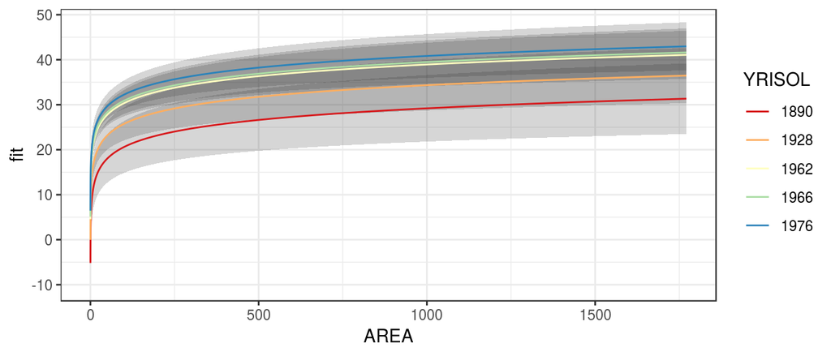

## Код для графика предсказаний модели: два предиктора

\[\widehat{ABUND}_i = -252.20 + 3.73 \cdot logAREA_i + 0.14 \cdot YRISOL_i\]

```r
# Искуственный датафрейм для предсказаний
MyData2 <- expand.grid(
  logAREA = seq(min(bird$logAREA), max(bird$logAREA), length.out = 100),
  YRISOL = round(quantile(bird$YRISOL)))
# Предсказанные значения
Predictions2 <- predict(mod5, newdata = MyData2,  interval = 'confidence')
MyData2 <- data.frame(MyData2, Predictions2)
# Обратная трансформация предиктора, который будем изображать
MyData2$AREA <- exp(MyData2$logAREA)
# Делаем год фактором
MyData2$YRISOL <- factor(MyData2$YRISOL)
# График предсказаний модели
Pl_predict2 <- ggplot(MyData2, aes(x = AREA, y = fit, group = YRISOL)) +
  geom_ribbon(alpha = 0.2, aes(ymin = lwr, ymax = upr)) +
  geom_line(aes(colour = YRISOL)) +
  scale_colour_brewer(palette = 'Spectral')
Pl_predict2
```

## Недостатки этой модели

\[\widehat{ABUND}_i = -252.20 + 3.73 \cdot logAREA_i + 0.14 \cdot YRISOL_i\]

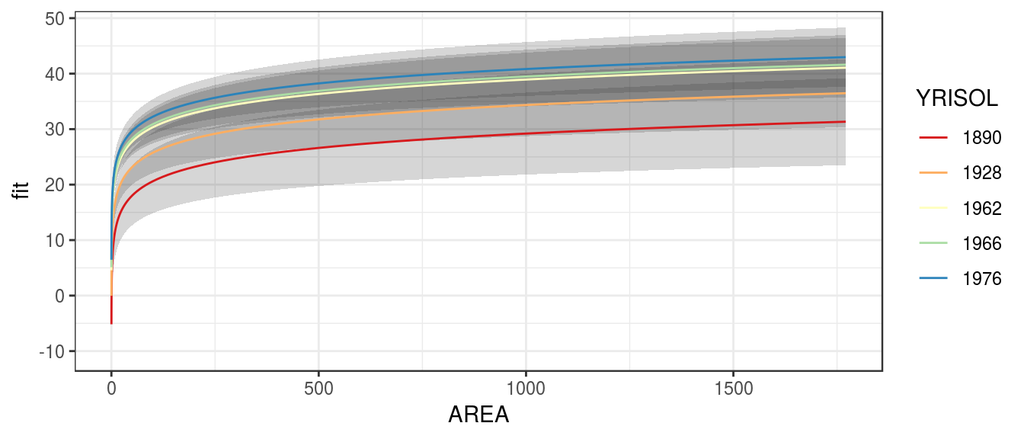

- отрицательные предсказания для очень давно изолированных маленьких лесов (обилие птиц не может быть отрицательным).
- не учтен уровень выпаса скота из-за колинеарности с другими предикторами (но он особенно интересен исследователям и остатки от него зависят).
- в выборке очень мало лесов большой площади — место, где кривая выходит на плато, плохо поддержано данными.

## Недостатки и ограничения методологии отбора моделей

- Разные способы отбора оптимальной модели могут приводить к разным результатам. Не важно, какой из способов выбрать, но важно сделать это заранее, **до анализа**, чтобы не поддаваться соблазну подгонять результаты.
- При отборе моделей приходится делать множество тестов, поэтому увеличивается риск ошибок I рода (подробнее на занятии про дисперсионный анализ). Чтобы хоть как-то себя обезопасить, лучше не включать в модель все подряд — только самое необходимое.
- Оптимальную модель лучше применять для тестирования гипотез на независимых данных, иначе получаются заниженные стандартные ошибки и завышенные эффекты. Обычно эту проблему игнорируют, но если у вас есть возможность, лучше сделать хотябы кросс-валидацию.
- Какой-то одной “лучшей” модели, как правило, не существует.

## Take-home messages

- Модели, которые качественно описывают существующие данные включают много параметров, но предсказания с их помощью менее точны из-за переобучения
- Для выбора оптимальной модели используются разные критерии в зависимости от задачи
- Сравнивая модели можно отбраковать переменные, включение которых в модель не улучшает ее
- **Метод сравнения моделей нужно выбрать заранее, еще до анализа**

## Что почитать

- Must read paper! Zuur, A.F. and Ieno, E.N., 2016. A protocol for conducting and presenting results of regression‐type analyses. Methods in Ecology and Evolution, 7(6), pp.636-645.
- Кабаков Р.И. R в действии. Анализ и визуализация данных на языке R. М.: ДМК Пресс, 2014
- Zuur, A., Ieno, E.N. and Smith, G.M., 2007. Analyzing ecological data. Springer Science & Business Media.
- Quinn G.P., Keough M.J. 2002. Experimental design and data analysis for biologists
- Logan M. 2010. Biostatistical Design and Analysis Using R. A Practical Guide